# Séance 2: Exemples de visualisation technique et non techniques

# Objectif

La première séance a pour but de se familiarer avec les différents graphiques réalisables avec R. Cette deuxième séance est divisée en deux parties:

- mieux comprendre certaines notions techniques
- mieux communiquer les informations sur les données

# Notions techniques

## Quelques généralités

Ne pas confondre corrélation et causalité (voir spurious correlation)

## Corrélation linéaire

Utiliser `corrplot` (du package éponyme) pour visualiser les corrélations linéaires entre les différentes variables (de la série de données `mtcars`, `iris`, `economics` par exemple).

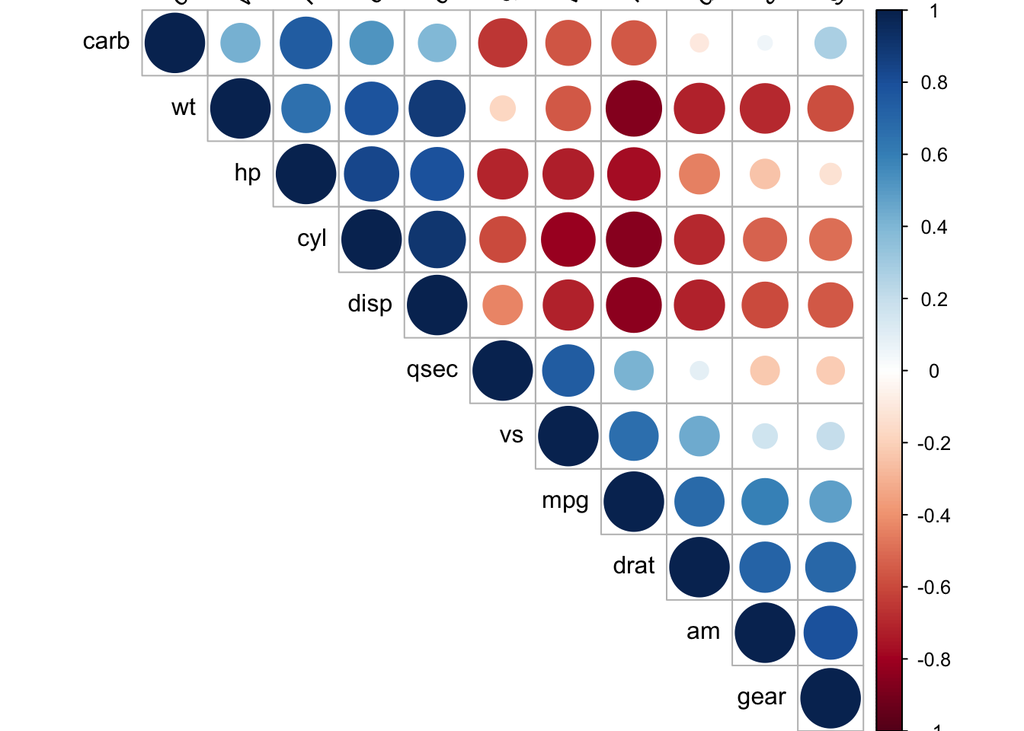

Utiliser la fonction `chart.Correlation` du package `PerformanceAnalytics`

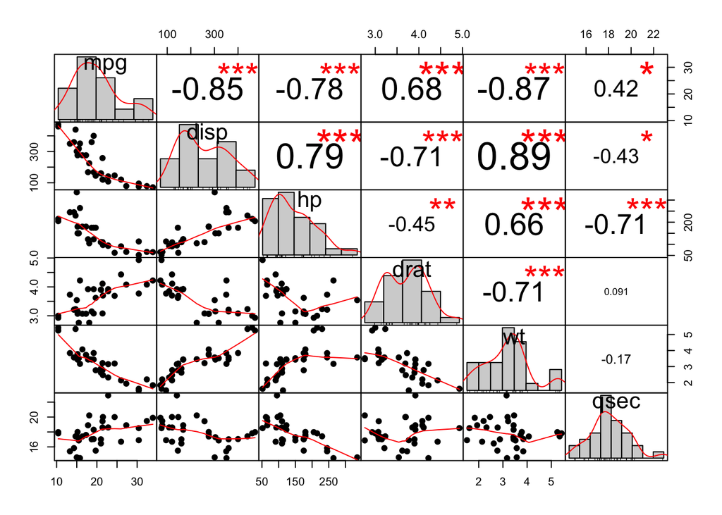

Utiliser un heatmap

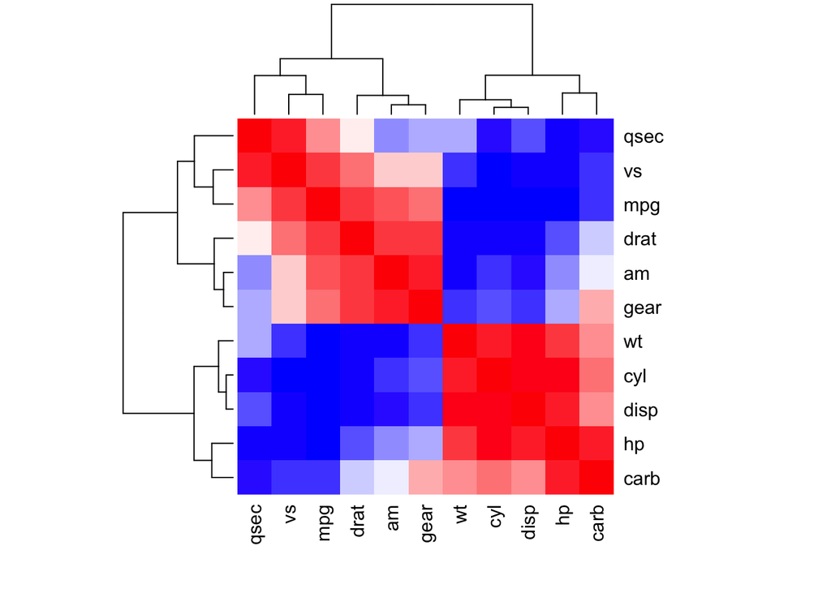

## Inconvénient de la corrélation linéaire

Etant données deux lois lognormales, on peut exprimer la corrélation linéaire en fonction de leurs paramètres.

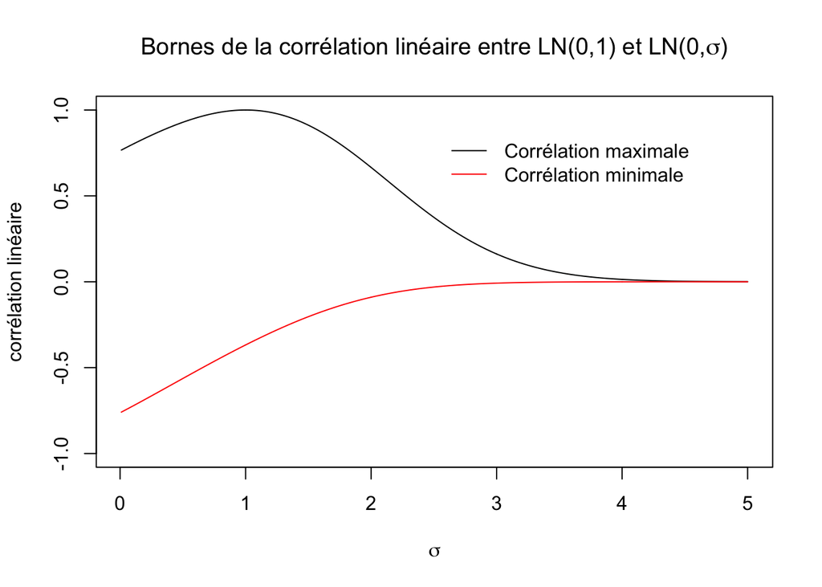

## Mesure de dépendance et copule

## Modélisation des courbes des taux et leur projection

- Copules, distribution, fonction de répartition, QQplot, Hill plot
- Simulation des nombres selon une loi donnée
- Modèles de taux

## Analyse de la sinistralité

- Chain Ladder et l’intervalle de confiance des ultimes

# Exploration des données

## Données

Les données sont sur les leurs sites

- [Données météorologiques](http://eca.knmi.nl/dailydata/index.php)
- [Données sur les sinistres automobiles corporels](https://www.data.gouv.fr/fr/datasets/base-de-donnees-accidents-corporels-de-la-circulation/)

Pour ceux qui du temps restant :

- [Correspondance code postal insee 2013 avec altitude, superficie, population et gécodage](http://public.opendatasoft.com/explore/dataset/correspondance-code-insee-code-postal/)
- [Carte des Codes Postaux 2016](http://datanova.legroupe.laposte.fr/explore/dataset/carte-des-codes-postaux/table/): données de la Poste, centroïdes des codes postaux
- [Catégories socio-professionnelles](http://public.opendatasoft.com/explore/dataset/evolution-et-structure-de-la-population-france-2012-categories-socio-professionn/information/)
- [Migrations résidentielles](http://public.opendatasoft.com/explore/dataset/evolution-et-structure-de-la-population-france-2012-migrations-residentielles/information/)
- [Résumés statistiques des communes, départements et régions](http://public.opendatasoft.com/explore/dataset/resume-statistique-communes-departements-et-regions-france-2012-2013-2014/)
- [Capacités des communes en hébergement touristique](http://public.opendatasoft.com/explore/dataset/capacite-des-communes-en-hebergement-touristique-2015/)
- [Revenus imposables et montants des impôts](http://public.opendatasoft.com/explore/dataset/revenus-imposables-et-montant-des-impots-1998-2005/)
- [Equipement sports et loisir par commune](http://public.opendatasoft.com/explore/dataset/equip-sport-loisir-socio-infra-2014/)
- [Décès par commune, départements et régions](http://public.opendatasoft.com/explore/dataset/deces-par-commune-departement-et-region-de-2003-a-2013/)

## Quelques suggestions de graphiques

Pour les données météorologiques, on peut choisir une ville donnée

- Evolution des températures (pression, quantité de pluie, etc) avec dygraphs
- Corrélation des différentes grandeurs
- Tendance et saisonnalité

Pour les données sur les accidents

- Analyse des lieux d’accidents
- Analyse des parties accidentées
- Evolution temporelles de certaines caractéristiques

Dans les deux cas, la situation géographique est très importante. Pour vous préparer la prochaine séance, vous pouvez lire la documentation sur [leafet pour R](https://rstudio.github.io/leaflet/).

## Habillage du graphique

Vous devez également prêter attention aux différents éléments suivants:

- Titre principal
- Titres des axes x et y
- Couleurs, formes des symboles
- Couleur de l’arrière-plan
- Polices des caractères
- Légende (position et textes)

# Interactivité

plotly

fonctionnement avec ggplot

Copyright © 2016 DatavISUP